# Assessment 3: Data Visualisation

2023-03-27

The final assessment will need you to pull together all the skills you have learned in this course. We would like you to make two data presentations based on the Malaria dataset you’ve already seen; the World Malaria Report.

We have provided you with cleaned versions of all datasets within the report [./wmr2022-clean-annexes/], though for reference you can also look at the original excel files [./wmr2022-excel-annexes/], and the [report itself](https://www.who.int/teams/global-malaria-programme/reports/world-malaria-report-2022)

Brief descriptions of the world malaria report files are in the file ‘wmr2022_file_notes.txt’

## Part 1

For Part 1, we would like to recreate - as closely as possible - a graphic we have made from the malaria modelling dataset. This graphic aims to show the contribution of 8 high-burden countries to the overall burden of malaria in Africa, and how this has changed since the year 2000.

### Please reproduce the following plot:

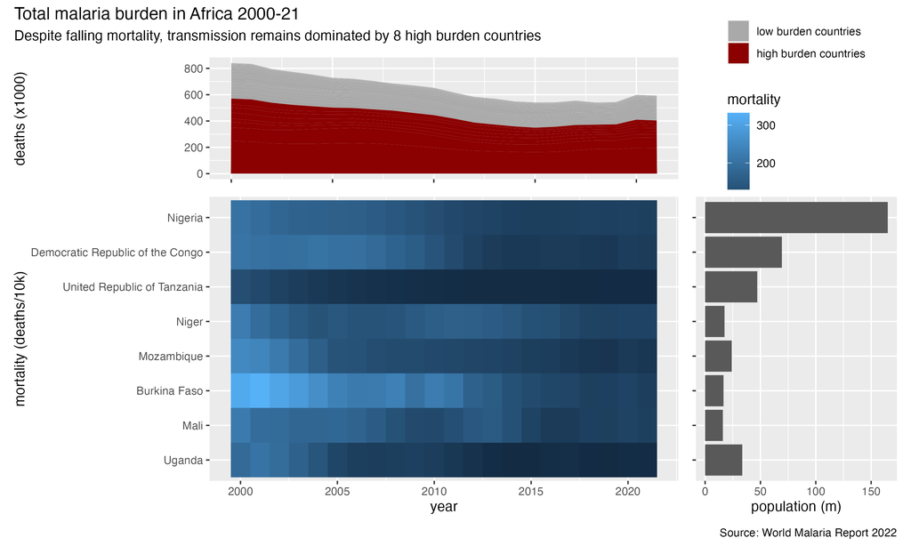

**The graphic consists of three sections:**

**Section (a)** a stacked plot of the total number of deaths from years 2000-2021. We have highlighted the remaining high-burden African countries (those which had more than 20,000 deaths in 2020); these are shown in red, the others are shown in grey.

**Section (b)** a heatmap of mortality for these high-burden countries across years 2000-2021. Mortality is expressed as the number of deaths per 10,000 people in the population.

**Section (c)** a bar plot of the mean population size in these countries from years 200-2021 (many of these populations have grown considerably in this period).

All three of these plots share axes; the guides are gathered into the remaining top-right quadrant.

All raw data necessary to produce this plot is in the file “wmr2022-clean-annexes/wmr_cases_deaths_modelling.txt”

## Part 2

### Tell us something about this data through a graph.

For part 2 you have complete editorial freedom to tell us something new about the data.

For example you could show us:

- Are there differences in malaria-causing species between countries within one continent?
- Are there broad differences in malaria-causing species between continents?
- Are there different drug regimes for different malaria species?
- How have case fatality rates changed over time?
- Are there places where nets are distributed but not used?
- Where is the reported data closest to the modelling data?
- Has the gap between reported data and modelling closed over time?
- How many nets/drugs are distributed for each dollar of funding?
- How effective are particular interventions?
- Or *any other question* you think can be answered with this, or other data

To do this you must use *at least one* item from the [./wmr2022-clean-annexes] folder. You can combine this with other data from the folder or you can combine this with other datasets you find online. Additional credit *will* be given for using external datasets.

**Please note:** The work is assessed on how well you have communicated your message through the graph. You **will not** be marked on the biological or epidemiological accuracy of your submitted work.

## Rules:

- All code should be clearly formatted and extensively commented
- All plots should be *as far as possible* self explanatory; titles and subtitles should be used to clarify the message.
- A narrative explanation of your plot (<500 words) should be included explaining:
  - what your plot is showing
  - why you have taken the design choices you did
  - why your geoms are appropriate
- External datasets should be publicly available and a link to the dataset should be included in your report.
- All code, text and plots should be submitted via *git* as the following files; each file should start with *your* student number:
  - [student_number]_assessment3_1.R <– figure 1 code
  - [student_number]_assessment3_1.png <– figure 2 image
  - [student_number]_assessment3_2.R <– figure 2 code
  - [student_number]_assessment3_2.png <– figure 2 image
  - [student_number]_assessment3_2.txt <– figure 2 narrative

## Marking Criteria

1. **Code quality**: Can we run the script as it is without error messages? Is it well annotated and properly formatted? Does it use succinct, but readable code, avoiding overly complicated solutions? (20/100 marks)
2. **Plot 1**: Does it show the correct data, do the geoms match the example and have annotations and themes been used correctly? (35/100 marks)
3. **Plot 2**: Are geoms appropriately chosen, is the message effectively communicated via the plot, does it use any external data? (35/100 marks)
4. **Narrative**: Does it use a rational choice of data, does the narrative match the plot, are geom and design choices justified? (15/100 marks)

## Submission

The assignment is released Monday 27th March 18:00 via email and due Friday 14th April 16:00.

You will submit your assignment by pushing the files to your GitHub repository.